# SMPE_Project

Imports for libraries that are used for the project. In this project ggplot2 has been used for data visualization. While gganimate is used for two animated visualizations in Task 3. For the animated visualizations to successfully run, the **png** package also needs to be installed.

```r
library("ggplot2")
library("gganimate")
library("gifski")
```

# Load the provided data

The data for this project is loaded and a summary of the data is presented, where we can spot if there is something strange with the data.

```r
df <- read.csv("https://raw.githubusercontent.com/vincentarelbundock/Rdatasets/master/csv/HistData/Wheat.csv", header=T, strip.white=TRUE);
```

```r
summary(df);
```

```
       X           Year          Wheat           Wages
 Min.   : 1   Min.   :1565   Min.   :26.00   Min.   : 5.000
 1st Qu.:14   1st Qu.:1630   1st Qu.:33.00   1st Qu.: 6.145
 Median :27   Median :1695   Median :41.00   Median : 7.800
 Mean   :27   Mean   :1695   Mean   :43.26   Mean   :11.582
 3rd Qu.:40   3rd Qu.:1760   3rd Qu.:47.00   3rd Qu.:14.875
 Max.   :53   Max.   :1821   Max.   :99.00   Max.   :30.000
                                             NA's   :3
```

# Dealing with missing data

From the summary above we can see that some values are missing, with the summary of **Wages** containing three missing values. In order to see which rows have missing values, they are extracted with the following code. After execution, we can see that the three rows containg missing values are rows *51*,*52* and *53*, were the wages values are missing. No other values are missing from the dataframe.

```r
missingData <- df[rowSums(is.na(df)) > 0,];
print(missingData);
```

|  | X | Year | Wheat | Wages |
| --- | --- | --- | --- | --- |
| 51 | 51 | 1815 | 78 | NA |
| 52 | 52 | 1820 | 54 | NA |
| 53 | 53 | 1821 | 54 | NA |

Here we remove the rows which contain the missing data. Then the new dataframe is printed where we can see that the new dataframe is now 50 rows (53 rows before removal of missing data). From the printed version we can see that the correct values are missing. A summary of the new data is also provided, where we can see that we don’t have any more missing data.

```r
newDF = na.omit(df);
print(newDF);
```

|  | X | Year | Wheat | Wages |
| --- | --- | --- | --- | --- |
| 1 | 1 | 1565 | 41.0 | 5.00 |
| 2 | 2 | 1570 | 45.0 | 5.05 |
| 3 | 3 | 1575 | 42.0 | 5.08 |
| 4 | 4 | 1580 | 49.0 | 5.12 |
| 5 | 5 | 1585 | 41.5 | 5.15 |
| 6 | 6 | 1590 | 47.0 | 5.25 |
| 7 | 7 | 1595 | 64.0 | 5.54 |
| 8 | 8 | 1600 | 27.0 | 5.61 |
| 9 | 9 | 1605 | 33.0 | 5.69 |
| 10 | 10 | 1610 | 32.0 | 5.78 |

[output cut: 40 more lines]

```r
summary(newDF);
```

```
       X              Year          Wheat
 Min.   : 1.00   Min.   :1565   Min.   :26.00
 1st Qu.:13.25   1st Qu.:1626   1st Qu.:32.25
 Median :25.50   Median :1688   Median :40.25
 Mean   :25.50   Mean   :1688   Mean   :42.14
 3rd Qu.:37.75   3rd Qu.:1749   3rd Qu.:45.75
 Max.   :50.00   Max.   :1810   Max.   :99.00
     Wages
 Min.   : 5.000
 1st Qu.: 6.145
 Median : 7.800
 Mean   :11.582
 3rd Qu.:14.875
 Max.   :30.000
```

# Sampled Periods

As additional preprocessing, we are going to check that the time between all sampled years is the same, as well as that we don’t have missing periods. After executing the following code, we know that there are no missing period and all sampled years are 5 years apart.

```r
l <- c()
len<-nrow(newDF)
i<-1
k<-1
currentYear<-0
while(i<len){
  if (i==1){
    currentYear<-newDF$Year[1]
  }else if(currentYear+5==newDF$Year[i]){
    currentYear<-currentYear+5
  } else{
    l[k]<-newDF$Year
    k <- k + 1
  }
  if(newDF$Year[i]%%5!=0){
    l[k]<-newDF$Year
    k <- k + 1
  }
  i <- i + 1
}
print(l)
```

[output not shown]

# Task 1

The first task is to create similar to the Playfair graph where we create a bar graph for the price of the wheat per 15 punds and with a line graph we indicate the wage per week. From the image provided compared to the graph bellow, we can conclude that we can reproduce this graph. The only notable difference between the two is the missing last three bars in our plot because we have removed the rows containing missing values, while in the original graph, those three bars are presented without the corresponding wages.

[figure not shown]

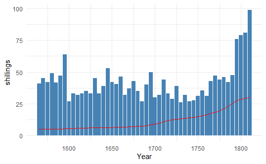

```r
ggplot(data=newDF, aes(x=Year, y= Wheat)) +
  geom_bar(stat = "identity", fill="steelblue")+
  geom_line(aes(y=Wages), colour="red")+
  theme_minimal() +
  labs(y = "shillings",x = "Year")
```

# Task 2

In this task, the visualization from the first tasks is improved by adding a second y axis, so that on one side we have the price of wheat for 15 pounds and on the other we have the weekly wage. The x axis stays the same, representing the years.

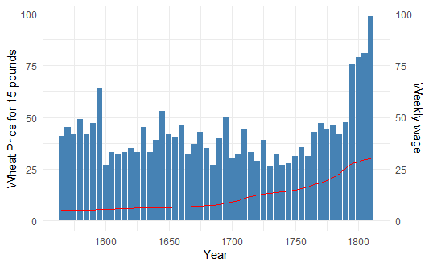

```r
ggplot(data=newDF, aes(x=Year, y= Wheat)) +
  geom_bar(stat = "identity", fill="steelblue")+
  geom_line(aes(y=Wages), colour="red")+
  theme_minimal() +
  scale_y_continuous(sec.axis = sec_axis(~.,name = "Weekly wage"))+
  labs(y = "Wheat Price for 15 pounds",
                x = "Year")
```